# Modulo 6 - Prima serie

Soluzioni

Author

Ottavia Epifania

# 1 Introduzione

Il presente caso studio richiede di eseguire delle procedure di analisi dei dati su un insieme di variabili associate a 70 candidati di un corso di laurea del nord-est (nota: questi dati sono già stati analizzati da un punto di vista descrittivo in un precedente Laboratorio R del Modulo 2).

# 2 Esercizi

Scaricare il file `datiTestCR2005.csv` e caricarlo in R assegnandolo alla variabile (data frame) DATITEST. Il file contiene un database con 70 osservazioni misurate su 7 variabili distinte:

1. `DIPAA` indica l’anno in cui lo studente ha ottenuto il suo diploma di scuola superiore;
2. `VOTO` è il voto di diploma ottenuto dallo studente (espresso in centesimi);
3. `SESSO` codifica il sesso dello studente (1: maschio, 2: femmina);
4. `D1` punteggio complessivo ad un test per la misura del ragionamento deduttivo: gamma di valori da 0 a 17;
5. `D2` punteggio complessivo ad un test per la misura del ragionamento spaziale: gamma di valori da 0 a 20;
6. `D3` punteggio complessivo ad un test per la misura del pensiero creativo: gamma di valori da 0 a 4;
7. `D4` punteggio complessivo ad un test per la comprensione di testi, grafici e tabelle: gamma di valori da 0 a 12.

```r
dati = read.csv2("datiTestCR2005.csv")
head(dati)
```

```
  DIPAA VOTO SESSO D1 D2 D3 D4
1  2005   63     2  9 17  2 11
2  1999   80     1 12 18  2  8
3  2005   64     1 11 17  2  5
4  2005   95     1  9 14  3  3
5  2005   93     2 13 18  4 12
6  2005   65     2  7 11  0 12
```

```r
str(dati)
```

```
'data.frame':   70 obs. of  7 variables:
 $ DIPAA: int  2005 1999 2005 2005 2005 2005 2004 2004 2005 2004 ...
 $ VOTO : int  63 80 64 95 93 65 60 100 76 100 ...
 $ SESSO: int  2 1 1 1 2 2 1 2 2 2 ...
 $ D1   : int  9 12 11 9 13 7 11 10 12 14 ...
 $ D2   : int  17 18 17 14 18 11 13 15 13 17 ...
 $ D3   : int  2 2 2 3 4 0 1 2 1 3 ...
 $ D4   : int  11 8 5 3 12 12 12 9 12 8 ...
```

```r
summary(dati)
```

```
     DIPAA           VOTO            SESSO             D1
 Min.   :1998   Min.   : 39.00   Min.   :1.000   Min.   : 5.00
 1st Qu.:2004   1st Qu.: 68.25   1st Qu.:1.000   1st Qu.: 9.00
 Median :2005   Median : 78.50   Median :2.000   Median :11.00
 Mean   :2004   Mean   : 78.11   Mean   :1.643   Mean   :10.79
 3rd Qu.:2005   3rd Qu.: 87.00   3rd Qu.:2.000   3rd Qu.:13.00
 Max.   :2005   Max.   :100.00   Max.   :2.000   Max.   :15.00
       D2              D3              D4
 Min.   : 7.00   Min.   :0.000   Min.   : 3.000
 1st Qu.:13.00   1st Qu.:1.000   1st Qu.: 9.000
 Median :14.00   Median :2.000   Median :10.000
 Mean   :14.36   Mean   :2.057   Mean   : 9.686
 3rd Qu.:17.00   3rd Qu.:3.000   3rd Qu.:11.000
 Max.   :20.00   Max.   :4.000   Max.   :12.000
```

## 2.1

Correggere la variabile `VOTO` secondo la modalità descritta nel Laboratorio R che ha analizzato lo stesso set di dati (ovvero, i valori fuori dal range vanno sostituiti con la media di `VOTO` calcolata sui soli valori all’interno del range).

```r
index = which(dati$VOTO < 60 | dati$VOTO > 100)
dati$VOTO[index] = mean(dati$VOTO[-index])
```

## 2.2

Visualizzare le statistiche descrittive di base per le variabili di tipo numerico. Aggiungere anche il calcolo della deviazione standard per tutte le variabili di tipo numerico

```r
summary(dati[,-3])
```

```
     DIPAA           VOTO              D1              D2
 Min.   :1998   Min.   : 60.00   Min.   : 5.00   Min.   : 7.00
 1st Qu.:2004   1st Qu.: 69.25   1st Qu.: 9.00   1st Qu.:13.00
 Median :2005   Median : 78.84   Median :11.00   Median :14.00
 Mean   :2004   Mean   : 78.68   Mean   :10.79   Mean   :14.36
 3rd Qu.:2005   3rd Qu.: 87.00   3rd Qu.:13.00   3rd Qu.:17.00
 Max.   :2005   Max.   :100.00   Max.   :15.00   Max.   :20.00
       D3              D4
 Min.   :0.000   Min.   : 3.000
 1st Qu.:1.000   1st Qu.: 9.000
 Median :2.000   Median :10.000
 Mean   :2.057   Mean   : 9.686
 3rd Qu.:3.000   3rd Qu.:11.000
 Max.   :4.000   Max.   :12.000
```

```r
apply(dati[,-3], 2, sd)
```

```
     DIPAA       VOTO         D1         D2         D3         D4
 1.1764599 12.0692360  2.3087286  3.1209238  0.9910573  2.1369276
```

## 2.3

Verificare se il voto medio di diploma del gruppo dei *maschi* sia significativamente differente dal voto medio di diploma del gruppo delle *femmine* (si consideri come livello di riferimento $\alpha = .05$). Quali conclusioni puoi trarre? Presentare i risultati con le oppurtune rappresentazioni grafiche

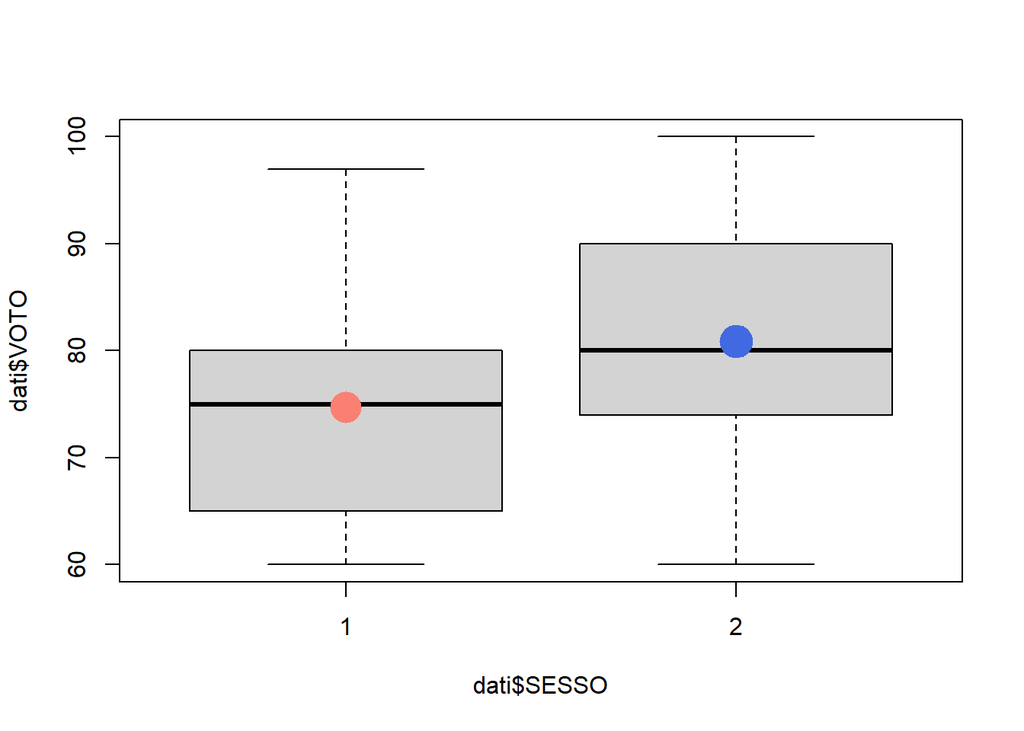

```r
boxplot(dati$VOTO ~ dati$SESSO)
points(c(1,2), c(mean(dati$VOTO[dati$SESSO == 1]), mean(dati$VOTO[dati$SESSO == 2])),
       pch = c(16, 19),col = c("salmon", "royalblue"),
       cex = 3)
```

```r
t.test(dati$VOTO[dati$SESSO ==1], dati$VOTO[dati$SESSO ==2])
```

```
    Welch Two Sample t-test

data:  dati$VOTO[dati$SESSO == 1] and dati$VOTO[dati$SESSO == 2]
t = -2.1451, df = 52.614, p-value = 0.03658
alternative hypothesis: true difference in means is not equal to 0
95 percent confidence interval:
 -11.9628181  -0.4004669
sample estimates:
mean of x mean of y
 74.70725  80.88889
```

```r
# analogo a
t.test(dati$VOTO ~ dati$SESSO)
```

```
    Welch Two Sample t-test

data:  dati$VOTO by dati$SESSO
t = -2.1451, df = 52.614, p-value = 0.03658
alternative hypothesis: true difference in means between group 1 and group 2 is not equal to 0
95 percent confidence interval:
 -11.9628181  -0.4004669
sample estimates:
mean in group 1 mean in group 2
       74.70725        80.88889
```

## 2.4

Derivare utilizzando le funzioni di riferimento di R il valore del p-value ed il valore critico della statistica target (considerato $\alpha = .05$).

```r
mytest = t.test(dati$VOTO ~ dati$SESSO) # assegna all'oggetto mytest i
# risultati

2*(1-pt(abs(mytest$statistic),mytest$parameter))   # calcolo del p-value
```

```
         t
0.03658469
```

```r
2*(pt(mytest$statistic,mytest$parameter))          # modo equivalente dato il segno
```

```
         t
0.03658469
```

```r
                                # del t osservato

qt(0.975,mytest$parameter)     # valore critico della statistica, test a due code
```

```
[1] 2.00609
```

## 2.5

Verificare se il voto medio di diploma degli studenti (indipendentemente dal genere) sia significativamente superiore a 70. Si richiede di testare l’ipotesi inferenziale utilizzando il confronto diretto tra il valore della statistica target osservata e il valore critico della statistica (assunto $\alpha = 0.05$).

```r
t.test(dati$VOTO, mu=70, alternative = "greater")
```

```
    One Sample t-test

data:  dati$VOTO
t = 6.0179, df = 69, p-value = 3.794e-08
alternative hypothesis: true mean is greater than 70
95 percent confidence interval:
 76.27609      Inf
sample estimates:
mean of x
 78.68116
```

```r
qt(0.95,69)    # calcolo del valore critico della
```

```
[1] 1.667239
```

```r
               # statistica pari a 1.667239 (test ad una coda dx)

# di conseguenza dato che il t osservato è maggiore del t critico
# concludo per il rigetto dell'ipotesi nulla (ovvero, il voto medio è
# significativamente superiore a 70)
```

## 2.6

Relativamente al gruppo delle *donne*, verificare la presenza di una differenza statisticamente significativa tra la variabile `ND1` e la variabile `ND2` (assunto $\alpha = 0.01$).

Nota: le variabili `ND1` e `ND2` sono le versioni normalizzate delle variabili originarie D1 e D2, mediante la seguente formula:

$$ND_i = \dfrac{D_i} {\max D_i}$$

dove $\max D_i$ fa riferimento al massimo valore *teorico* di $D_i$. Quali conclusioni puoi trarre? Presentare i risultati con le oppurtune rappresentazioni grafiche

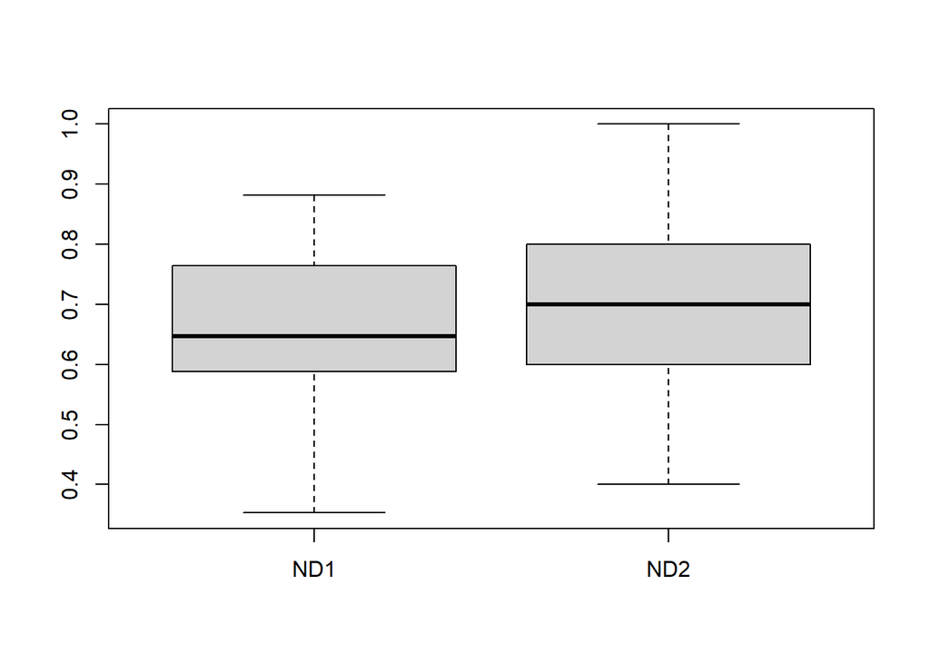

```r
# 17 e 20 sono i valori massimi teorici delle variabili D1 d D2
# rispettivamente
dati$ND1 = dati$D1/17
dati$ND2 = dati$D2/20

boxplot(dati$ND1[dati$SESSO==2], dati$ND2[dati$SESSO==2], names = c("ND1", "ND2"))
```

```r
t.test(dati$ND1[dati$SESSO==2],
       dati$ND2[dati$SESSO==2],paired=T)
```

```
    Paired t-test

data:  dati$ND1[dati$SESSO == 2] and dati$ND2[dati$SESSO == 2]
t = -1.8153, df = 44, p-value = 0.07629
alternative hypothesis: true mean difference is not equal to 0
95 percent confidence interval:
 -0.104268061  0.005444532
sample estimates:
mean difference
    -0.04941176
```

## 2.7

Ripetere la stessa analisi questa volta sul gruppo dei maschi.

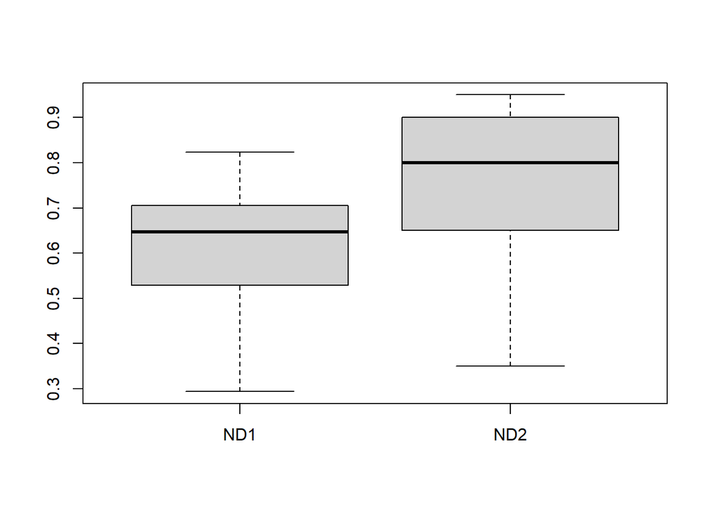

```r
boxplot(dati$ND1[dati$SESSO==1], dati$ND2[dati$SESSO==1], names = c("ND1", "ND2"))
```

```r
t.test(dati$ND1[dati$SESSO==1],
       dati$ND2[dati$SESSO==1],paired=T)
```

```
    Paired t-test

data:  dati$ND1[dati$SESSO == 1] and dati$ND2[dati$SESSO == 1]
t = -4.0424, df = 24, p-value = 0.0004733
alternative hypothesis: true mean difference is not equal to 0
95 percent confidence interval:
 -0.21840878 -0.07076769
sample estimates:
mean difference
     -0.1445882
```